# Homework 4: greedy algorithm for teaching OLS; 1NN classifier

Ruixuan Tu (ruixuan@cs.wisc.edu)

4 March 2023

# Setup

Load packages and set working directory:

```r
knitr::opts_knit$set(root.dir = "/Users/turx/Projects/machine-teaching-23sp/hw04-greedy-1nn")
knitr::opts_chunk$set(warning = FALSE, message = FALSE, error = FALSE)
library(readxl)
library(tidyverse)
library(lubridate)
library(ggplot2)
set.seed(27021)
```

# Q1: When enumeration stops working?

## Read data (from Homework 3)

```r
pool <- read.table("../hw03-machine-teaching-ols/hw3pool.txt", col.names = c("x", "y"))
pool
```

```
##           x          y
## 1  2.374862  1.0802890
## 2  2.946939  1.8986054
## 3  1.650485  1.8640327
## 4  3.270571  2.6910741
## 5  1.168345 -3.0322151
## 6  1.443327 -1.1253668
## 7  2.869272  3.3632392
## 8  2.695933  1.9037783
## 9  1.450013  2.0780165
## 10 1.638038 -0.1211598
## 11 1.978955  1.3904179
## 12 1.186760 -0.9483188
## 13 2.001471 -0.3276148
## 14 2.585486  3.1464462
```

[output cut: 16 more lines]

## Implementation of OLS, combinatorial selector, and fitter (modified from Homework 3)

```r
ols_regression_single <- function(x, y) {
  model <- lm(y ~ x)
  return(list(m = model$coefficients[2], b = model$coefficients[1]))
}

# define closeness
closeness <- function(m, b, mhat, bhat) (mhat - m)^2 + (bhat - b)^2

# generate the set of all multi-subsets of size m from a set of size n given by index 1:n
# an equivalent problem: generate the set of all tuples of n non-negative integers with sum m
gen_tuples <- function(n, m) {
  if (n == 1) {
    return(list(c(m)))
  } else {
    v <- list()
    for (i in 0:m) {
      v <- c(v, lapply(gen_tuples(n - 1, m - i), function(x) c(i, x)))
    }
    return(v)
  }
}

# select the best multi-subset of size n from the dataset df with variables x and y
combinatorial_selector <- function(df, n, verbose = FALSE, history = NA) {
  if (n < 2) stop("n must be greater than 1")
  # generate all multi-subsets of size n
  tuples <- gen_tuples(nrow(df), n)
  # generate the multi-subsets
  # an element v_i in tuple v means the number of times the i-th point is selected
  multisets <- map(tuples, function(v) {
    multiset <- list(x = c(), y = c())
    for (i in seq_along(v)) {
      multiset$x <- c(multiset$x, rep(df$x[i], v[i]))
      multiset$y <- c(multiset$y, rep(df$y[i], v[i]))
    }
    return(multiset)
  })
  if (verbose) cat("Number of multi-subsets:", length(multisets), "\n")
  # calculate the closeness of each multi-subset
  closenesses <- map_dbl(multisets, function(s) {
    reg <- ols_regression_single(s$x, s$y)
    return(closeness(2, -3, reg$m, reg$b))
  })
  # drop NA, as if we select n points be the same, the closeness is NA
  min_closeness <- min(closenesses, na.rm = TRUE)
  if (is.na(min_closeness)) {
    return(list(
      tuple = NULL,
      multiset = NULL,
      closeness = NA
    ))
  }
  # return the best tuple and its closeness
  best_idx <- which(closenesses == min_closeness)
  return(list(
    multiset = multisets[[best_idx]],
    closeness = min_closeness,
    n = length(tuples)
  ))
}

pool_fit <- function(n, selector, verbose = FALSE, history = NA) {
  start_time <- Sys.time()
  d <- selector(df = pool, n = n, history = history)
  df_selected <- tibble(
    x = d$multiset$x,
    y = d$multiset$y
  )
  model <- ols_regression_single(df_selected$x, df_selected$y)
  end_time <- Sys.time()
  if (verbose) {
    cat("\nBest dataset (use the first one):\n")
    print(d)
    cat("\nModel of linear regression on the best dataset:\n")
    print(model)
    cat("Time elapsed (second):", end_time - start_time, "\n")
    cat("[pool_fit] x =", d$multiset$x, " y =", d$multiset$y, "\n")
  }
  return(list(
    x = d$multiset$x,
    y = d$multiset$y,
    loss = d$closeness,
    n_ols = d$n_ols,
    time = end_time - start_time
  ))
}
```

## Test when enumeration stops working

```r
pool_fit_batch <- function(upper, selector, file) {
  if (!file.exists(file)) {
    pool_fit_results <- tibble(x = list(), y = list(), n_pts = integer(), n_ols = integer(), loss = double(), time = double())
    for (n in 2:upper) {
      history_row_df <- pool_fit_results[nrow(pool_fit_results), ]
      history <- list(x = unlist(history_row_df$x), y = unlist(history_row_df$y))
      result <- pool_fit(n, selector, history = history)
      pool_fit_results <- rbind(pool_fit_results, tibble(x = list(result$x), y = list(result$y), n_pts = n, n_ols = result$n_ols, loss = result$loss, time = result$time))
    }
    pool_fit_results <- pool_fit_results %>% select(-x, -y)
  } else {
    pool_fit_results <- read_csv(file, col_types = cols(n_pts = col_integer(), n_ols = col_integer(), loss = col_double(), time = col_double()))
  }
  pool_fit_results <- pool_fit_results %>% mutate(loss = num(loss, notation = "sci"))
  if (!file.exists(file))
    write_csv(pool_fit_results, file)
  return(pool_fit_results)
}

# plot n_pts vs. log(loss) curve
plot_fit_result <- function(pool_fit_results, title) {
  p <- ggplot(pool_fit_results, aes(x = n_pts, y = loss)) +
    geom_point() +
    geom_line() +
    scale_y_log10() +
    labs(x = "Number of points", y = "Loss (scaled log10)") +
    ggtitle("Log of loss vs. number of points", subtitle = title)
  ggsave(paste0(title, "_plot.svg"), p)
  p
}
```

```r
pool_fit_comb_results <- pool_fit_batch(
  upper = 6,
  selector = combinatorial_selector,
  file = "q1_pool_fit_comb_results.csv"
)
pool_fit_comb_results %>% print(n = Inf)
```

[output not shown]

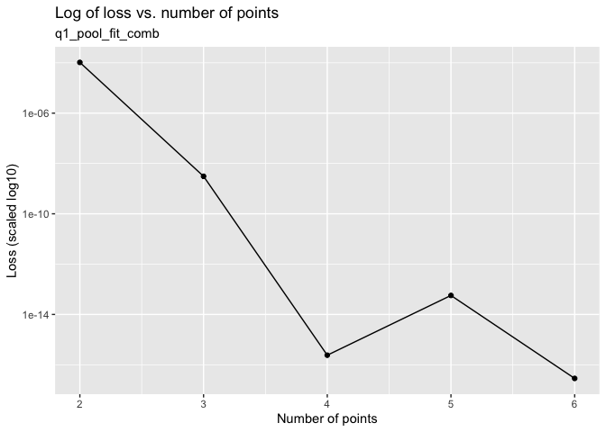

```r
plot_fit_result(pool_fit_comb_results, "q1_pool_fit_comb")
```

## Intepretation

As the enumeration for the combinatorial selector of size 6 takes 418 seconds, and it is extremely slow for larger sizes (waited more than 10 minutes for size 7), we stop the enumeration at size 6.

# Q2: A greedy algorithm

## Implementation of the greedy algorithm

```r
greedy_selector <- function(df, n, history) {
  if (length(history$x) >= 2 && length(history$x) != n - 1) stop("n is not for +1")
  n_ols <- 0
  if (length(history$x) >= 2) {
    df_selected <- tibble(x = history$x, y = history$y)
  } else {
    # select the first point
    initial_idx <- sample(nrow(df), 1)
    initial_point <- df[initial_idx, ]
    df_selected <- tibble(x = initial_point$x, y = initial_point$y)
  }
  min_global_closeness <- Inf
  lower <- 2
  if (length(history$x) >= 2)
    lower <- length(history$x) + 1
  for (i in lower:n) {
    min_closeness <- Inf
    min_idx <- NA
    for (j in seq_len(nrow(df))) {
      pending_df_selected <- rbind(df_selected, df[j, ])
      theta_hat <- ols_regression_single(pending_df_selected$x, pending_df_selected$y)
      n_ols <- n_ols + 1
      pending_closeness <- closeness(2, -3, theta_hat$m, theta_hat$b)
      if (is.na(pending_closeness)) next
      if (pending_closeness < min_closeness) {
        min_closeness <- pending_closeness
        min_idx <- j
      }
    }
    min_global_closeness <- min_closeness
    df_selected <- rbind(df_selected, df[min_idx, ])
  }
  return(list(
    multiset = list(x = df_selected$x, y = df_selected$y),
    closeness = min_global_closeness,
    n_ols = n_ols
  ))
}
```

## Use the greedy algorithm

```r
pool_fit_greedy_results <- pool_fit_batch(
  upper = nrow(pool),
  greedy_selector,
  file = "q2_pool_fit_greedy_results.csv"
)
pool_fit_greedy_results %>% print(n = Inf)
```

[output not shown]

[output cut: 17 more lines]

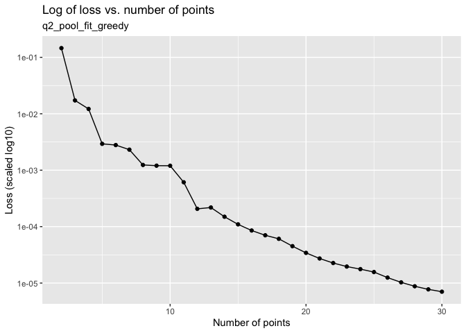

```r
plot_fit_result(pool_fit_greedy_results, "q2_pool_fit_greedy")
```

## Interpretation

```r
pool_fit_greedy_results %>% filter(loss == min(pool_fit_greedy_results$loss))
```

[output not shown]

```r
pool_fit_comb_results %>% filter(loss == min(pool_fit_comb_results$loss))
```

[output not shown]

The greedy algorithm is worse than the combinatorial algorithm, as the loss is higher (the difference between losses with max 6 points for the combinatorial selector and max 30 points for the greedy selector is significant), which means a lower quality of the teaching set. The stopping criterion I might use is that there is no lower loss which can refresh the min loss in consecutive 5 points, as selecting multiset does not need to restrict the number of selected points to be the size of the pool $P$. In terms of running time, the greedy algorithm is much faster, and the time cost to add a point is constant, not exponential like the combinatorial algorithm.

# Q3: Implement kNN classifier

## Implementation of dataset generatior

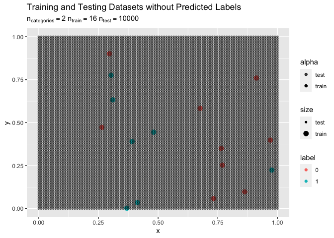

```r
# generate a dataset with n vectors of dimension d, with n_categories categories of labels
generator_unif <- function(n_vec, d, n_categories) {
  x <- matrix(runif(n_vec * d), n_vec, d)
  y <- sample.int(n_categories, n_vec, replace = TRUE) - 1
  return(list(x = x, y = y))
}

# generate a dataset on a grid with n_categories categories of labels
generator_grid <- function(x_min, x_max, y_min, y_max, len, n_categories) {
  x <- seq(x_min, x_max, length.out = len)
  y <- seq(y_min, y_max, length.out = len)
  x <- expand.grid(x, y)
  x <- as.matrix(x)
  y <- sample.int(n_categories, len * len, replace = TRUE) - 1
  return(list(x = x, y = y))
}

# plot the training and testing datasets, with testing dataset in not predicted
plot_dataset <- function(ds_train, ds_test, n_categories, k = 0) {
  plot <- ggplot() +
    geom_point(data = tibble(x = ds_train$x[, 1], y = ds_train$x[, 2], label = ds_train$y), aes(x, y, color = factor(label), size = "train", alpha = "train")) +
    scale_color_discrete(name = "label", labels = paste((1:n_categories) - 1)) +
    scale_size_manual(values = c("train" = 3, "test" = 1)) +
    scale_alpha_manual(values = c("train" = 1, "test" = 0.5)) +
    xlim(0, 1) +
    ylim(0, 1)
  if (length(table(ds_test$y)) > 1) {
    plot <- plot +
      geom_point(data = tibble(x = ds_test$x[, 1], y = ds_test$x[, 2], label = ds_test$y), aes(x, y, color = factor(label), size = "test", alpha = "test")) +
      ggtitle(
        "Training and Testing Datasets with Predicted Labels",
        subtitle = bquote(n[categories] == .(n_categories) ~ n[train] == .(nrow(ds_train$x)) ~ n[test] == .(nrow(ds_test$x)) ~ k == .(k))
      )
    ggsave(paste0("q3_plot_cat", n_categories, "_train", nrow(ds_train$x), "_test", nrow(ds_test$x), "_k", k, ".svg"), plot)
  } else {
    plot <- plot +
      geom_point(data = tibble(x = ds_test$x[, 1], y = ds_test$x[, 2]), aes(x, y, size = "test", alpha = "test")) +
      ggtitle(
        "Training and Testing Datasets without Predicted Labels",
        subtitle = bquote(n[categories] == .(n_categories) ~ n[train] == .(nrow(ds_train$x)) ~ n[test] == .(nrow(ds_test$x)))
      )
    ggsave(paste0("q3_cat", n_categories, "_train", nrow(ds_train$x), "_test", nrow(ds_test$x), "_np.svg"), plot)
  }
  plot
}

ds_train <- generator_unif(n_vec = 16, d = 2, n_categories = 2)
ds_test <- generator_grid(x_min = 0, x_max = 1, y_min = 0, y_max = 1, len = 100, n_categories = 1)
plot_dataset(ds_train, ds_test, n_categories = 2)
```

## Implementation of kNN classifier

```r
knn_classifier <- function(train_x, train_y, test_x, k) {
  test_y <- integer(nrow(test_x))
  for (i in seq_len(nrow(test_x))) {
    # compute the distance between the test point and all training points
    distances <- map_dbl(seq_len(nrow(train_x)), function(j) sqrt(sum((train_x[j, ] - test_x[i, ]) ^ 2)))
    # find the k nearest neighbors
    nearest_neighbors <- train_y[order(distances)[1:k]]
    # predict the label of the test point
    test_y_single <- as.integer(names(which.max(table(nearest_neighbors))))
    # store the prediction
    test_y[i] <- test_y_single
  }
  return(test_y)
}
```

## Test the kNN classifier for a certain dataset

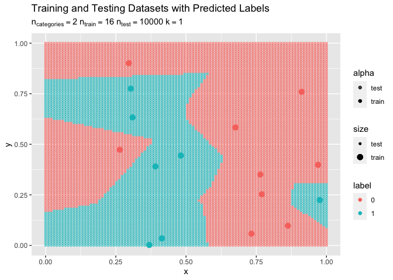

```r
ds_test_pred <- tibble(x = ds_test$x, y = knn_classifier(ds_train$x, ds_train$y, ds_test$x, k = 1))
plot_dataset(ds_train, ds_test_pred, n_categories = 2, k = 1)
```

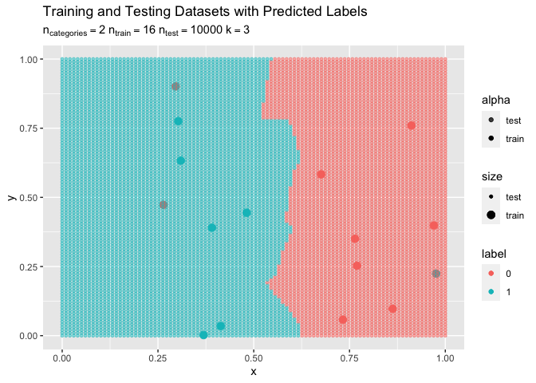

```r
ds_test_pred <- tibble(x = ds_test$x, y = knn_classifier(ds_train$x, ds_train$y, ds_test$x, k = 3))
plot_dataset(ds_train, ds_test_pred, n_categories = 2, k = 3)
```

## One more complicated dataset with 4 categories

[figure not shown]

```r
ds_train <- generator_unif(n_vec = 32, d = 2, n_categories = 4)
ds_test <- generator_grid(x_min = 0, x_max = 1, y_min = 0, y_max = 1, len = 100, n_categories = 1)
ds_test_pred <- tibble(x = ds_test$x, y = knn_classifier(ds_train$x, ds_train$y, ds_test$x, k = 3))
plot_dataset(ds_train, ds_test_pred, n_categories = 4, k = 4)
```